# Part II - FordGo Bike Sharing Data Analysis

## by Abdur-Roqeeb Ismail

## Investigation Overview

In this investigation, I wanted to check for features that can be used to predict where and when most trips occured. I also want to know how characteristics of users (gender, age group and user type) affect the duration of the trips.

## Dataset Overview

This data set includes information about individual rides made in a bike-sharing system covering the greater San Francisco Bay area. The dataset contained 16 columns and 183412 rows. I perfomed a preliminary wrangking on the data and the shape of the data became 24 columns and 174952 after data cleaning and feature engineering.

## Distribution of trips by days of the week.

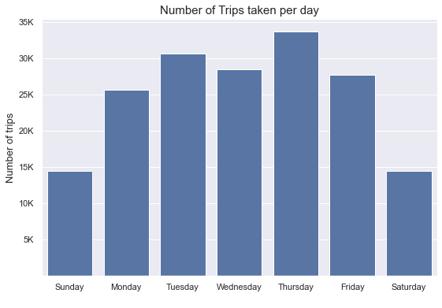

## Distribution of Member Gender

A large proportion of the bike users are male.

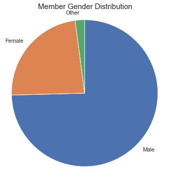

## Top 10 start and end stations.

The station at Market Street at 10th Street was the station where most trips started from , while most trips ended at San Francisco Caltrain Station 2. Most of the stations where most trips occured are around Market Street.

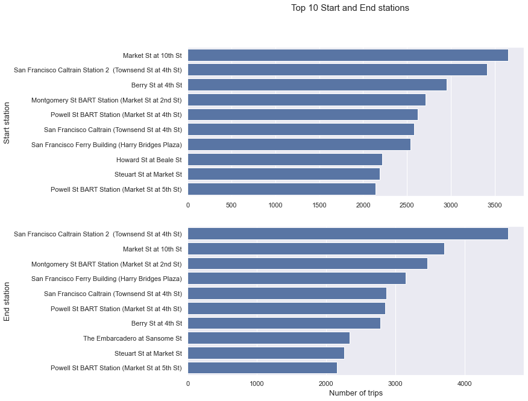

## Effect of user type on Average Duration of trips.

The trips take by customers lasted longer on an average than those by subscribers. Infact average duration of trips by customers is twice as long as that by subscribers.

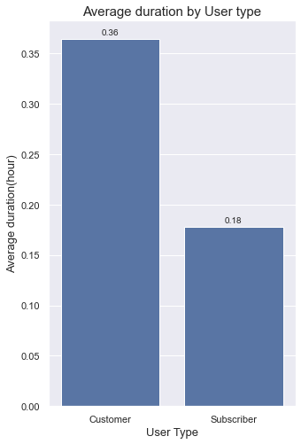